# Midterm

# 6) Cross-Validation and Priors

Now we’ll need to check the predictive ability of our models and specifically if the relationship is truley linear or not. To do this we’ll try using cross-validation to see if we fit our data better with a linear model or if we fit it better with a higher order formula.

I find the AIC table for our various models to be one of the best ways to see this fit

```r
#Create our new object
morph_aic <- data.frame(polynomial = c(1:5),
                          names = c("linear",
                                    "quadratic",
                                    "cubic",
                                    "quartic",
                                    "quintic")) %>%

  #Go rowwise through it
  rowwise() %>%

  #Add each lm as a member of a list column
  mutate(mods = list(lm(Culmen..mm. ~ poly(Tarsus..mm., polynomial),
                    data = morph)))

#Calculate the AIC table
aic_table <- aictab(cand.set = morph_aic$mods,
                    modnames = morph_aic$names)

#Display our data
gt(aic_table) %>%

  #Set up the tab header
  tab_header(
    title = "AIC Table for different polynomial fits") %>%

  #Align it to the center
  opt_align_table_header(align = "center") %>%

  #Stripe the rows to make it more readable
  opt_row_striping(row_striping = TRUE)
```

AIC Table for different polynomial fits

| Modnames | K | AICc | Delta_AICc | ModelLik | AICcWt | LL | Cum.Wt |
| --- | --- | --- | --- | --- | --- | --- | --- |
| cubic | 5 | 2481.702 | 0.000000 | 1.000000e+00 | 6.356238e-01 | -1235.811 | 0.6356238 |
| quartic | 6 | 2483.667 | 1.965140 | 3.743477e-01 | 2.379443e-01 | -1235.778 | 0.8735681 |
| quintic | 7 | 2484.932 | 3.229906 | 1.989000e-01 | 1.264256e-01 | -1235.392 | 0.9999937 |
| linear | 3 | 2505.395 | 23.692989 | 7.163626e-06 | 4.553371e-06 | -1249.682 | 0.9999982 |
| quadratic | 4 | 2507.293 | 25.591504 | 2.772525e-06 | 1.762283e-06 | -1249.620 | 1.0000000 |

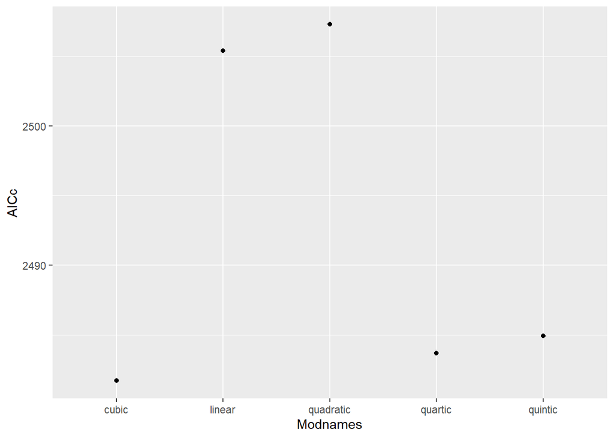

```r
ggplot(data = aic_table,
       aes(x = Modnames,
           y = AICc))+
  geom_point()
```

Looking at this through the lens of AICc we can see that we still show the cubic model to be the best fit for this data as it shows the lowest AICc value.

As we can also see from this table, the AICc Weight for the cubic model is much much larger than any other model at 63%. This means that this model contains 63% of the “predictive power” that this set of models represents.